# Project: Wrangling and Analyze Data

```python
# Convert all possible columns to integers
for column in tweets_json_df.columns:
    try:
        # Convert to numeric, setting errors='coerce' will replace non-numeric values with NaNs
        tweets_json_df[column] = pd.to_numeric(tweets_json_df[column], errors='coerce').astype('Int64')
    except ValueError:
        print(f"Column '{column}' cannot be converted to integers.")

# Display the DataFrame after converting columns to integers
display(tweets_json_df.head())

# Display information about the dataset to confirm the data types
tweets_json_df.info()
```

|  | created_at | id | id_str | full_text | truncated | display_text_range | source | in_reply_to_status_id | in_reply_to_status_id_str | in_reply_to_user_id | ... | user_profile_sidebar_fill_color | user_profile_text_color | user_profile_use_background_image | user_has_extended_profile | user_default_profile | user_default_profile_image | user_following | user_follow_request_sent | user_notifications | user_translator_type |
| --- | --- | --- | --- | --- | --- | --- | --- | --- | --- | --- | --- | --- | --- | --- | --- | --- | --- | --- | --- | --- | --- |
| 0 | <NA> | 892420643555336193 | 892420643555336193 | <NA> | 0 | <NA> | <NA> | <NA> | <NA> | <NA> | ... | 0 | 0 | 0 | 1 | 0 | 0 | 1 | 0 | 0 | <NA> |
| 1 | <NA> | 892177421306343426 | 892177421306343426 | <NA> | 0 | <NA> | <NA> | <NA> | <NA> | <NA> | ... | 0 | 0 | 0 | 1 | 0 | 0 | 1 | 0 | 0 | <NA> |
| 2 | <NA> | 891815181378084864 | 891815181378084864 | <NA> | 0 | <NA> | <NA> | <NA> | <NA> | <NA> | ... | 0 | 0 | 0 | 1 | 0 | 0 | 1 | 0 | 0 | <NA> |
| 3 | <NA> | 891689557279858688 | 891689557279858688 | <NA> | 0 | <NA> | <NA> | <NA> | <NA> | <NA> | ... | 0 | 0 | 0 | 1 | 0 | 0 | 1 | 0 | 0 | <NA> |
| 4 | <NA> | 891327558926688256 | 891327558926688256 | <NA> | 0 | <NA> | <NA> | <NA> | <NA> | <NA> | ... | 0 | 0 | 0 | 1 | 0 | 0 | 1 | 0 | 0 | <NA> |

5 rows × 76 columns

```
<class 'pandas.core.frame.DataFrame'>
RangeIndex: 2354 entries, 0 to 2353
Data columns (total 76 columns):
 #   Column                                   Non-Null Count  Dtype
---  ------                                   --------------  -----
 0   created_at                               0 non-null      Int64
 1   id                                       2354 non-null   Int64
 2   id_str                                   2354 non-null   Int64
 3   full_text                                0 non-null      Int64
 4   truncated                                2354 non-null   Int64
 5   display_text_range                       0 non-null      Int64
 6   source                                   0 non-null      Int64
 7   in_reply_to_status_id                    78 non-null     Int64
 8   in_reply_to_status_id_str                78 non-null     Int64
 9   in_reply_to_user_id                      78 non-null     Int64
```

[output cut: 68 more lines]

```python
# Check for duplicates in tweet data
duplicate_tweets = tweets_json_df.duplicated()
print(f"Number of duplicate rows in tweet data: {duplicate_tweets.sum()}")

# If there are duplicates, display them
if duplicate_tweets.sum() > 0:
    print("Duplicate rows in tweet data:")
    display(tweets_json_df[duplicate_tweets])

# Remove duplicate rows
tweets_json_cleaned = tweets_json_df.drop_duplicates()

# Display the number of rows after removing duplicates
print(f"Number of rows after removing duplicates: {len(tweets_json_cleaned)}")
```

```
Number of duplicate rows in tweet data: 0
Number of rows after removing duplicates: 2354
```

```
Retweet counts statistics:
count         2354.0
mean     3164.797366
std      5284.770364
min              0.0
25%            624.5
50%           1473.5
75%           3652.0
max          79515.0
Name: retweet_count, dtype: Float64
Favorite counts statistics:
count          2354.0
mean      8080.968564
std      11814.771334
min               0.0
25%            1415.0
50%            3603.5
75%          10122.25
max          132810.0
Name: favorite_count, dtype: Float64
```

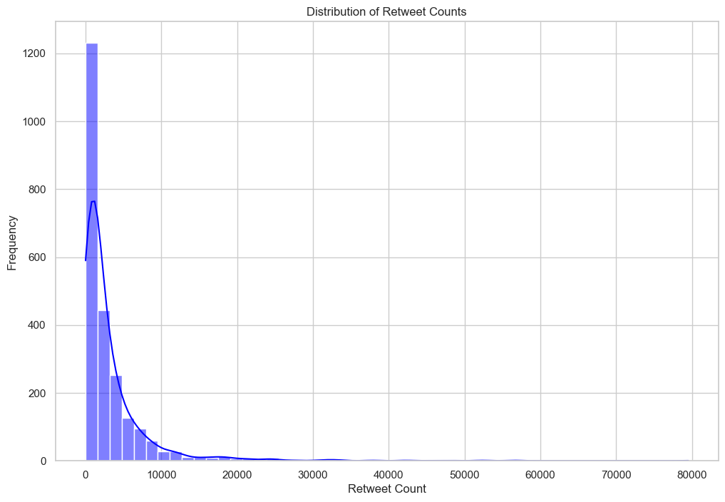

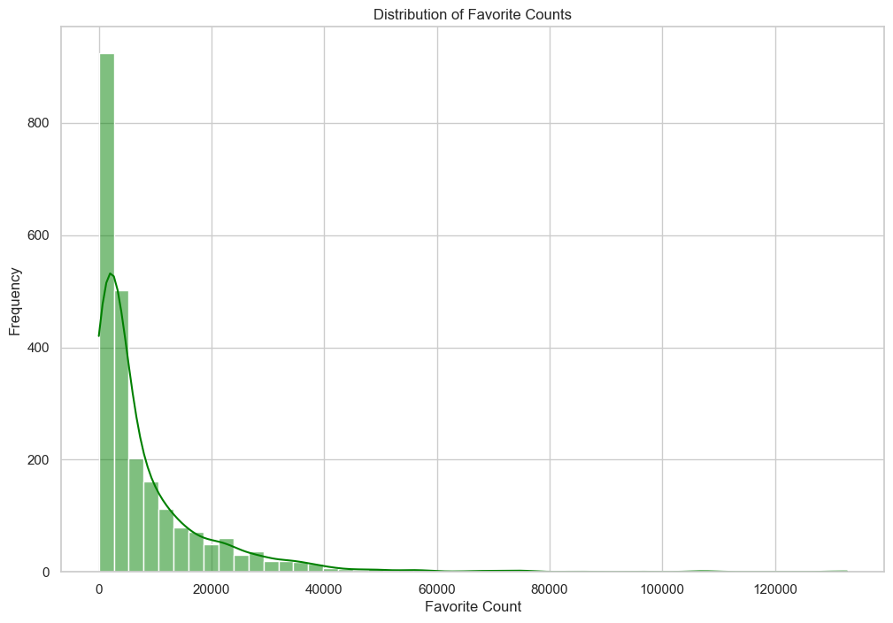

```python
# Analyzing retweet counts
retweet_counts = tweets_json_cleaned['retweet_count'].describe()
print("Retweet counts statistics:")
print(retweet_counts)

# Analyzing favorite counts
favorite_counts = tweets_json_cleaned['favorite_count'].describe()
print("Favorite counts statistics:")
print(favorite_counts)

# Visualizing the distribution of retweet counts
import matplotlib.pyplot as plt
import seaborn as sns

plt.figure(figsize=(12, 8))
sns.histplot(tweets_json_cleaned['retweet_count'], bins=50, kde=True, color='blue')
plt.title('Distribution of Retweet Counts')
plt.xlabel('Retweet Count')
plt.ylabel('Frequency')
plt.show()

# Visualizing the distribution of favorite counts
plt.figure(figsize=(12, 8))
sns.histplot(tweets_json_cleaned['favorite_count'], bins=50, kde=True, color='green')
plt.title('Distribution of Favorite Counts')
plt.xlabel('Favorite Count')
plt.ylabel('Frequency')
plt.show()
```

## Assessing Data

In this section, detect and document at least **eight (8) quality issues and two (2) tidiness issue**. You must use **both** visual assessment programmatic assessement to assess the data.

**Note:** pay attention to the following key points when you access the data.

- You only want original ratings (no retweets) that have images. Though there are 5000+ tweets in the dataset, not all are dog ratings and some are retweets.
- Assessing and cleaning the entire dataset completely would require a lot of time, and is not necessary to practice and demonstrate your skills in data wrangling. Therefore, the requirements of this project are only to assess and clean at least 8 quality issues and at least 2 tidiness issues in this dataset.
- The fact that the rating numerators are greater than the denominators does not need to be cleaned. This [unique rating system](http://knowyourmeme.com/memes/theyre-good-dogs-brent) is a big part of the popularity of WeRateDogs.
- You do not need to gather the tweets beyond August 1st, 2017. You can, but note that you won't be able to gather the image predictions for these tweets since you don't have access to the algorithm used.

# Assessing Data

In this section, detect and document at least eight (8) quality issues and two (2) tidiness issues. You must use both visual assessment and programmatic assessment to assess the data.

**Note**: Pay attention to the following key points when you access the data:

- You only want original ratings (no retweets) that have images. Though there are 5000+ tweets in the dataset, not all are dog ratings and some are retweets.
- Assessing and cleaning the entire dataset completely would require a lot of time and is not necessary to practice and demonstrate your skills in data wrangling. Therefore, the requirements of this project are only to assess and clean at least 8 quality issues and at least 2 tidiness issues in this dataset.
- The fact that the rating numerators are greater than the denominators does not need to be cleaned. This unique rating system is a big part of the popularity of WeRateDogs.
- You do not need to gather tweets beyond August 1st, 2017. You can, but note that you won't be able to gather the image predictions for these tweets since you don't have access to the algorithm used.

## Quality Issues

1. **Missing Values**:
   - Some columns have significant missing values (e.g., `in_reply_to_status_id`, `in_reply_to_user_id`, `retweeted_status_id`, `retweeted_status_user_id`, `retweeted_status_timestamp`).
2. **Erroneous Datatypes**:
   - Some columns are not in the correct datatype (e.g., `timestamp` should be a datetime object, `tweet_id` should be a string).
3. **Retweets and Replies**:
   - The dataset contains retweets and replies, which should be filtered out to only include original tweets.
4. **Inconsistent Ratings**:
   - Some `rating_numerator` and `rating_denominator` values are inconsistent with the typical rating system used by WeRateDogs.
5. **Expanded URLs**:
   - Some `expanded_urls` are missing or broken.
6. **Dog Stage Values**:
   - Multiple columns (`doggo`, `floofer`, `pupper`, `puppo`) contain missing values and should be combined into a single `dog_stage` column.
7. **Incorrect Dog Breed Predictions**:
   - In the `image_predictions` dataset, some dog breeds might have incorrect or misleading names (e.g., mixed breeds).
8. **Non-Dog Images**:
   - Some entries in the `image_predictions` dataset might not be dog images.

## Tidiness Issues

1. **Dog Stage Columns**:
   - The `doggo`, `floofer`, `pupper`, `puppo` columns should be combined into a single `dog_stage` column.
2. **Separate Datasets**:
   - The `twitter_archive`, `image_predictions`, and `tweet_json_df` datasets should be merged into a single DataFrame for easier analysis.

## Programmatic Assessment

```
import pandas as pd

# Load the datasets
twitter_archive = pd.read_csv('/mnt/data/twitter-archive-enhanced (2).csv')
image_predictions = pd.read_csv('/mnt/data/image-predictions (1).tsv', sep='\t')

tweets_data = []
with open('/mnt/data/tweet-json copy') as file:
    for line in file:
        tweets_data.append(json.loads(line))
tweets_json_df = pd.DataFrame(tweets_data)

# Display information about each dataset
print("Twitter Archive:")
twitter_archive.info()
print("\nImage Predictions:")
image_predictions.info()
print("\nTweets JSON:")
tweets_json_df.info()

# Checking for missing values
print("Missing values in Twitter Archive:")
print(twitter_archive.isnull().sum())
print("\nMissing values in Image Predictions:")
print(image_predictions.isnull().sum())
print("\nMissing values in Tweets JSON:")
print(tweets_json_df.isnull().sum())

# Checking data types
print("Data types in Twitter Archive:")
print(twitter_archive.dtypes)
print("\nData types in Image Predictions:")
print(image_predictions.dtypes)
print("\nData types in Tweets JSON:")
print(tweets_json_df.dtypes)

# Checking for duplicates
print("Duplicates in Twitter Archive:")
print(twitter_archive.duplicated().sum())
print("\nDuplicates in Image Predictions:")
print(image_predictions.duplicated().sum())
print("\nDuplicates in Tweets JSON:")
print(tweets_json_df.duplicated().sum())
```

### Quality issues

```python
import pandas as pd

# Load the datasets
twitter_archive = pd.read_csv('twitter-archive-enhanced (2).csv')
image_predictions = pd.read_csv('image-predictions (1).tsv', sep='\t')
```

```python
tweets_data = []
with open('tweet-json copy') as file:
    for line in file:
        tweets_data.append(json.loads(line))
tweets_json_df = pd.DataFrame(tweets_data)
```

```python
# Display information about each dataset
print("Twitter Archive:")
twitter_archive.info()
print("\nImage Predictions:")
image_predictions.info()
print("\nTweets JSON:")
tweets_json_df.info()
```

```
Twitter Archive:
<class 'pandas.core.frame.DataFrame'>
RangeIndex: 2356 entries, 0 to 2355
Data columns (total 17 columns):
 #   Column                      Non-Null Count  Dtype
---  ------                      --------------  -----
 0   tweet_id                    2356 non-null   int64
 1   in_reply_to_status_id       78 non-null     float64
 2   in_reply_to_user_id         78 non-null     float64
 3   timestamp                   2356 non-null   object
 4   source                      2356 non-null   object
 5   text                        2356 non-null   object
 6   retweeted_status_id         181 non-null    float64
 7   retweeted_status_user_id    181 non-null    float64
 8   retweeted_status_timestamp  181 non-null    object
 9   expanded_urls               2297 non-null   object
 10  rating_numerator            2356 non-null   int64
 11  rating_denominator          2356 non-null   int64
 12  name                        1611 non-null   object
 13  doggo                       97 non-null     object
 14  floofer                     10 non-null     object
 15  pupper                      257 non-null    object
 16  puppo                       30 non-null     object
dtypes: float64(4), int64(3), object(10)
memory usage: 313.0+ KB

Image Predictions:
<class 'pandas.core.frame.DataFrame'>
RangeIndex: 2075 entries, 0 to 2074
Data columns (total 12 columns):
 #   Column    Non-Null Count  Dtype
---  ------    --------------  -----
 0   tweet_id  2075 non-null   int64
 1   jpg_url   2075 non-null   object
 2   img_num   2075 non-null   int64
 3   p1        2075 non-null   object
 4   p1_conf   2075 non-null   float64
 5   p1_dog    2075 non-null   bool
 6   p2        2075 non-null   object
 7   p2_conf   2075 non-null   float64
```

[output cut: 31 more lines]

```
 18  contributors                   0 non-null      object
 19  is_quote_status                2354 non-null   bool
 20  retweet_count                  2354 non-null   int64
 21  favorite_count                 2354 non-null   int64
 22  favorited                      2354 non-null   bool
 23  retweeted                      2354 non-null   bool
 24  possibly_sensitive             2211 non-null   object
 25  possibly_sensitive_appealable  2211 non-null   object
 26  lang                           2354 non-null   object
 27  retweeted_status               179 non-null    object
 28  quoted_status_id               29 non-null     float64
 29  quoted_status_id_str           29 non-null     object
 30  quoted_status                  28 non-null     object
dtypes: bool(4), float64(3), int64(3), object(21)
memory usage: 505.9+ KB
```

```python
# Checking for missing values
print("Missing values in Twitter Archive:")
print(twitter_archive.isnull().sum())
print("\nMissing values in Image Predictions:")
print(image_predictions.isnull().sum())
print("\nMissing values in Tweets JSON:")
print(tweets_json_df.isnull().sum())
```

```
Missing values in Twitter Archive:
tweet_id                         0
in_reply_to_status_id         2278
in_reply_to_user_id           2278
timestamp                        0
source                           0
text                             0
retweeted_status_id           2175
retweeted_status_user_id      2175
retweeted_status_timestamp    2175
expanded_urls                   59
rating_numerator                 0
rating_denominator               0
name                           745
doggo                         2259
floofer                       2346
pupper                        2099
puppo                         2326
dtype: int64

Missing values in Image Predictions:
tweet_id    0
jpg_url     0
img_num     0
p1          0
p1_conf     0
p1_dog      0
p2          0
p2_conf     0
p2_dog      0
p3          0
p3_conf     0
p3_dog      0
dtype: int64

Missing values in Tweets JSON:
created_at                          0
id                                  0
id_str                              0
full_text                           0
```

[output cut: 13 more lines]

```
place                            2353
contributors                     2354
is_quote_status                     0
retweet_count                       0
favorite_count                      0
favorited                           0
retweeted                           0
possibly_sensitive                143
possibly_sensitive_appealable     143
lang                                0
retweeted_status                 2175
quoted_status_id                 2325
quoted_status_id_str             2325
quoted_status                    2326
dtype: int64
```

```python
# Checking data types
print("Data types in Twitter Archive:")
print(twitter_archive.dtypes)
print("\nData types in Image Predictions:")
print(image_predictions.dtypes)
print("\nData types in Tweets JSON:")
print(tweets_json_df.dtypes)
```

```
Data types in Twitter Archive:
tweet_id                        int64
in_reply_to_status_id         float64
in_reply_to_user_id           float64
timestamp                      object
source                         object
text                           object
retweeted_status_id           float64
retweeted_status_user_id      float64
retweeted_status_timestamp     object
expanded_urls                  object
rating_numerator                int64
rating_denominator              int64
name                           object
doggo                          object
floofer                        object
pupper                         object
puppo                          object
dtype: object

Data types in Image Predictions:
tweet_id      int64
jpg_url      object
img_num       int64
p1           object
p1_conf     float64
p1_dog         bool
p2           object
p2_conf     float64
p2_dog         bool
p3           object
p3_conf     float64
p3_dog         bool
dtype: object

Data types in Tweets JSON:
created_at                        object
id                                 int64
id_str                            object
full_text                         object
```

[output cut: 13 more lines]

```
place                             object
contributors                      object
is_quote_status                     bool
retweet_count                      int64
favorite_count                     int64
favorited                           bool
retweeted                           bool
possibly_sensitive                object
possibly_sensitive_appealable     object
lang                              object
retweeted_status                  object
quoted_status_id                 float64
quoted_status_id_str              object
quoted_status                     object
dtype: object
```

```python
# Convert relevant columns to integers
for column in tweets_json_df.columns:
    try:
        # Attempt to convert each column to integer, handling non-numeric values by converting them to NaNs first
        tweets_json_df[column] = pd.to_numeric(tweets_json_df[column], errors='coerce').astype('Int64')
    except ValueError:
        print(f"Column '{column}' cannot be converted to integers.")

# Display the DataFrame after converting columns to integers
display(tweets_json_df.head())

# Display information about the dataset to confirm the data types
tweets_json_df.info()
```

|  | created_at | id | id_str | full_text | truncated | display_text_range | entities | extended_entities | source | in_reply_to_status_id | ... | favorite_count | favorited | retweeted | possibly_sensitive | possibly_sensitive_appealable | lang | retweeted_status | quoted_status_id | quoted_status_id_str | quoted_status |
| --- | --- | --- | --- | --- | --- | --- | --- | --- | --- | --- | --- | --- | --- | --- | --- | --- | --- | --- | --- | --- | --- |
| 0 | <NA> | 892420643555336193 | 892420643555336193 | <NA> | 0 | <NA> | <NA> | <NA> | <NA> | <NA> | ... | 39467 | 0 | 0 | 0 | 0 | <NA> | <NA> | <NA> | <NA> | <NA> |
| 1 | <NA> | 892177421306343426 | 892177421306343426 | <NA> | 0 | <NA> | <NA> | <NA> | <NA> | <NA> | ... | 33819 | 0 | 0 | 0 | 0 | <NA> | <NA> | <NA> | <NA> | <NA> |
| 2 | <NA> | 891815181378084864 | 891815181378084864 | <NA> | 0 | <NA> | <NA> | <NA> | <NA> | <NA> | ... | 25461 | 0 | 0 | 0 | 0 | <NA> | <NA> | <NA> | <NA> | <NA> |
| 3 | <NA> | 891689557279858688 | 891689557279858688 | <NA> | 0 | <NA> | <NA> | <NA> | <NA> | <NA> | ... | 42908 | 0 | 0 | 0 | 0 | <NA> | <NA> | <NA> | <NA> | <NA> |
| 4 | <NA> | 891327558926688256 | 891327558926688256 | <NA> | 0 | <NA> | <NA> | <NA> | <NA> | <NA> | ... | 41048 | 0 | 0 | 0 | 0 | <NA> | <NA> | <NA> | <NA> | <NA> |

5 rows × 31 columns

```
<class 'pandas.core.frame.DataFrame'>
RangeIndex: 2354 entries, 0 to 2353
Data columns (total 31 columns):
 #   Column                         Non-Null Count  Dtype
---  ------                         --------------  -----
 0   created_at                     0 non-null      Int64
 1   id                             2354 non-null   Int64
 2   id_str                         2354 non-null   Int64
 3   full_text                      0 non-null      Int64
 4   truncated                      2354 non-null   Int64
 5   display_text_range             0 non-null      Int64
 6   entities                       0 non-null      Int64
 7   extended_entities              0 non-null      Int64
 8   source                         0 non-null      Int64
 9   in_reply_to_status_id          78 non-null     Int64
```

[output cut: 23 more lines]

```python
# Check for duplicates in tweet data
duplicate_tweets = tweets_json_df.duplicated()
print(f"Number of duplicate rows in tweet data: {duplicate_tweets.sum()}")

# If there are duplicates, display them
if duplicate_tweets.sum() > 0:
    print("Duplicate rows in tweet data:")
    display(tweets_json_df[duplicate_tweets])

# Remove duplicate rows
tweets_json_cleaned = tweets_json_df.drop_duplicates()

# Display the number of rows after removing duplicates
print(f"Number of rows after removing duplicates: {len(tweets_json_cleaned)}")
```

```
Number of duplicate rows in tweet data: 0
Number of rows after removing duplicates: 2354
```

# Assessing Data

In this section, detect and document at least eight (8) quality issues and two (2) tidiness issues. You must use both visual assessment and programmatic assessment to assess the data.

**Note**: Pay attention to the following key points when you access the data:

- You only want original ratings (no retweets) that have images. Though there are 5000+ tweets in the dataset, not all are dog ratings and some are retweets.
- Assessing and cleaning the entire dataset completely would require a lot of time and is not necessary to practice and demonstrate your skills in data wrangling. Therefore, the requirements of this project are only to assess and clean at least 8 quality issues and at least 2 tidiness issues in this dataset.
- The fact that the rating numerators are greater than the denominators does not need to be cleaned. This unique rating system is a big part of the popularity of WeRateDogs.
- You do not need to gather tweets beyond August 1st, 2017. You can, but note that you won't be able to gather the image predictions for these tweets since you don't have access to the algorithm used.

## Quality Issues

1. **Missing Values**:
   - Some columns have significant missing values (e.g., `in_reply_to_status_id`, `in_reply_to_user_id`, `retweeted_status_id`, `retweeted_status_user_id`, `retweeted_status_timestamp`).
2. **Erroneous Datatypes**:
   - Some columns are not in the correct datatype (e.g., `timestamp` should be a datetime object, `tweet_id` should be a string).
3. **Retweets and Replies**:
   - The dataset contains retweets and replies, which should be filtered out to only include original tweets.
4. **Inconsistent Ratings**:
   - Some `rating_numerator` and `rating_denominator` values are inconsistent with the typical rating system used by WeRateDogs.
5. **Expanded URLs**:
   - Some `expanded_urls` are missing or broken.
6. **Dog Stage Values**:
   - Multiple columns (`doggo`, `floofer`, `pupper`, `puppo`) contain missing values and should be combined into a single `dog_stage` column.
7. **Incorrect Dog Breed Predictions**:
   - In the `image_predictions` dataset, some dog breeds might have incorrect or misleading names (e.g., mixed breeds).
8. **Non-Dog Images**:
   - Some entries in the `image_predictions` dataset might not be dog images.

## Tidiness Issues

1. **Dog Stage Columns**:
   - The `doggo`, `floofer`, `pupper`, `puppo` columns should be combined into a single `dog_stage` column.
2. **Separate Datasets**:
   - The `twitter_archive`, `image_predictions`, and `tweet_json_df` datasets should be merged into a single DataFrame for easier analysis.

## Programmatic Assessment

```
import pandas as pd

# Load the datasets
twitter_archive = pd.read_csv('/mnt/data/twitter-archive-enhanced (2).csv')
image_predictions = pd.read_csv('/mnt/data/image-predictions (1).tsv', sep='\t')

tweets_data = []
with open('/mnt/data/tweet-json copy') as file:
    for line in file:
        tweets_data.append(json.loads(line))
tweets_json_df = pd.DataFrame(tweets_data)

# Display information about each dataset
print("Twitter Archive:")
twitter_archive.info()
print("\nImage Predictions:")
image_predictions.info()
print("\nTweets JSON:")
tweets_json_df.info()

# Checking for missing values
print("Missing values in Twitter Archive:")
print(twitter_archive.isnull().sum())
print("\nMissing values in Image Predictions:")
print(image_predictions.isnull().sum())
print("\nMissing values in Tweets JSON:")
print(tweets_json_df.isnull().sum())

# Checking data types
print("Data types in Twitter Archive:")
print(twitter_archive.dtypes)
print("\nData types in Image Predictions:")
print(image_predictions.dtypes)
print("\nData types in Tweets JSON:")
print(tweets_json_df.dtypes)

# Handling list and dictionary columns before checking for duplicates
list_dict_columns = []
for column in tweets_json_df.columns:
    if isinstance(tweets_json_df[column].iloc[0], (list, dict)):
        list_dict_columns.append(column)
        print(f"Column '{column}' contains {type(tweets_json_df[column].iloc[0]).__name__} data type.")

# Flatten list and dictionary columns
for column in list_dict_columns:
    # Flatten list columns by converting lists to string representations
    if isinstance(tweets_json_df[column].iloc[0], list):
        tweets_json_df[column] = tweets_json_df[column].apply(lambda x: ', '.join(map(str, x)) if isinstance(x, list) else x)
    # Flatten dictionary columns by expanding dict keys into separate columns
    elif isinstance(tweets_json_df[column].iloc[0], dict):
        dict_keys = tweets_json_df[column].iloc[0].keys()
        for key in dict_keys:
            tweets_json_df[f"{column}_{key}"] = tweets_json_df[column].apply(lambda x: x.get(key) if isinstance(x, dict) else None)
        tweets_json_df.drop(columns=[column], inplace=True)

# Checking for duplicates
print("Duplicates in Twitter Archive:")
print(twitter_archive.duplicated().sum())
print("\nDuplicates in Image Predictions:")
print(image_predictions.duplicated().sum())
print("\nDuplicates in Tweets JSON:")
print(tweets_json_df.duplicated().sum())

# Convert relevant columns to integers
for column in tweets_json_df.columns:
    try:
        # Attempt to convert each column to integer, handling non-numeric values by converting them to NaNs first
        tweets_json_df[column] = pd.to_numeric(tweets_json_df[column], errors='coerce').astype('Int64')
    except ValueError:
        print(f"Column '{column}' cannot be converted to integers.")

# Display the DataFrame after converting columns to integers
display(tweets_json_df.head())

# Display information about the dataset to confirm the data types
tweets_json_df.info()
```

## Cleaning Data

In this section, clean **all** of the issues you documented while assessing.

**Note:** Make a copy of the original data before cleaning. Cleaning includes merging individual pieces of data according to the rules of [tidy data](https://cran.r-project.org/web/packages/tidyr/vignettes/tidy-data.html). The result should be a high-quality and tidy master pandas DataFrame (or DataFrames, if appropriate).

# Cleaning Data

In this section, clean all of the issues you documented while assessing.

**Note**: Make a copy of the original data before cleaning. Cleaning includes merging individual pieces of data according to the rules of tidy data. The result should be a high-quality and tidy master pandas DataFrame (or DataFrames, if appropriate).

## Make copies of original pieces of data

```
# Make copies of original pieces of data
twitter_archive_clean = twitter_archive.copy()
image_predictions_clean = image_predictions.copy()
tweets_json_clean = tweets_json_df.copy()
```

```python
# Make copies of original pieces of data
twitter_archive_clean = twitter_archive.copy()
image_predictions_clean = image_predictions.copy()
tweets_json_clean = tweets_json_df.copy()
```

### Issue #1:Missing Values

#### Define:

Identify and handle columns with significant missing values. Specifically, drop columns with a large number of missing values that are not essential for analysis.

#### Code

```python
# Check for missing values in the datasets
print("Missing values in Twitter Archive:")
print(twitter_archive_clean.isnull().sum())
print("\nMissing values in Image Predictions:")
print(image_predictions_clean.isnull().sum())
print("\nMissing values in Tweets JSON:")
print(tweets_json_clean.isnull().sum())

# Drop columns in twitter_archive_clean with a large number of missing values if they are not essential
columns_to_drop = ['in_reply_to_status_id', 'in_reply_to_user_id', 'retweeted_status_id', 'retweeted_status_user_id', 'retweeted_status_timestamp']
twitter_archive_clean = twitter_archive_clean.drop(columns=columns_to_drop)

# Display the updated dataframe information
print("\nUpdated Twitter Archive after dropping columns with many missing values:")
twitter_archive_clean.info()
```

```
Missing values in Twitter Archive:
tweet_id                         0
in_reply_to_status_id         2278
in_reply_to_user_id           2278
timestamp                        0
source                           0
text                             0
retweeted_status_id           2175
retweeted_status_user_id      2175
retweeted_status_timestamp    2175
expanded_urls                   59
rating_numerator                 0
rating_denominator               0
name                           745
doggo                         2259
floofer                       2346
pupper                        2099
puppo                         2326
dtype: int64

Missing values in Image Predictions:
tweet_id    0
jpg_url     0
img_num     0
p1          0
p1_conf     0
p1_dog      0
p2          0
p2_conf     0
p2_dog      0
p3          0
p3_conf     0
p3_dog      0
dtype: int64

Missing values in Tweets JSON:
created_at                       2354
id                                  0
id_str                              0
full_text                        2354
```

[output cut: 34 more lines]

```
---  ------              --------------  -----
 0   tweet_id            2356 non-null   int64
 1   timestamp           2356 non-null   object
 2   source              2356 non-null   object
 3   text                2356 non-null   object
 4   expanded_urls       2297 non-null   object
 5   rating_numerator    2356 non-null   int64
 6   rating_denominator  2356 non-null   int64
 7   name                1611 non-null   object
 8   doggo               97 non-null     object
 9   floofer             10 non-null     object
 10  pupper              257 non-null    object
 11  puppo               30 non-null     object
dtypes: int64(3), object(9)
memory usage: 221.0+ KB
```

### Issue #2:Erroneous Datatypes

#### Define

Convert columns to appropriate datatypes. Specifically, convert the timestamp column to a datetime object and the tweet_id column to a string.

#### Code

```python
# Convert timestamp to datetime
twitter_archive_clean['timestamp'] = pd.to_datetime(twitter_archive_clean['timestamp'])

# Convert tweet_id to string
twitter_archive_clean['tweet_id'] = twitter_archive_clean['tweet_id'].astype(str)
image_predictions_clean['tweet_id'] = image_predictions_clean['tweet_id'].astype(str)
tweets_json_clean['id_str'] = tweets_json_clean['id_str'].astype(str)

# Display the updated dataframe information
print("Twitter Archive Data Types After Conversion:")
print(twitter_archive_clean.dtypes)
print("\nImage Predictions Data Types After Conversion:")
print(image_predictions_clean.dtypes)
print("\nTweets JSON Data Types After Conversion:")
print(tweets_json_clean.dtypes)
```

```
Twitter Archive Data Types After Conversion:
tweet_id                           object
timestamp             datetime64[ns, UTC]
source                             object
text                               object
expanded_urls                      object
rating_numerator                    int64
rating_denominator                  int64
name                               object
doggo                              object
floofer                            object
pupper                             object
puppo                              object
dtype: object

Image Predictions Data Types After Conversion:
tweet_id     object
jpg_url      object
img_num       int64
p1           object
p1_conf     float64
p1_dog         bool
p2           object
p2_conf     float64
p2_dog         bool
p3           object
p3_conf     float64
p3_dog         bool
dtype: object

Tweets JSON Data Types After Conversion:
created_at                        Int64
id                                Int64
id_str                           object
full_text                         Int64
truncated                         Int64
display_text_range                Int64
entities                          Int64
extended_entities                 Int64
source                            Int64
```

[output cut: 8 more lines]

```
place                             Int64
contributors                      Int64
is_quote_status                   Int64
retweet_count                     Int64
favorite_count                    Int64
favorited                         Int64
retweeted                         Int64
possibly_sensitive                Int64
possibly_sensitive_appealable     Int64
lang                              Int64
retweeted_status                  Int64
quoted_status_id                  Int64
quoted_status_id_str              Int64
quoted_status                     Int64
dtype: object
```

Issue #3: Retweets and Replies

```python
# Filter out retweets and replies to include only original tweets
if 'retweeted_status_id' in twitter_archive_clean.columns:
    twitter_archive_clean = twitter_archive_clean[twitter_archive_clean['retweeted_status_id'].isnull()]

if 'in_reply_to_status_id' in twitter_archive_clean.columns:
    twitter_archive_clean = twitter_archive_clean[twitter_archive_clean['in_reply_to_status_id'].isnull()]

# Drop the columns for retweets and replies as they are no longer needed
columns_to_drop = ['retweeted_status_id', 'retweeted_status_user_id', 'retweeted_status_timestamp', 'in_reply_to_status_id', 'in_reply_to_user_id']
columns_to_drop = [col for col in columns_to_drop if col in twitter_archive_clean.columns]
twitter_archive_clean = twitter_archive_clean.drop(columns=columns_to_drop)

# Display the updated dataframe information
print("Twitter Archive After Filtering Out Retweets and Replies:")
twitter_archive_clean.info()
```

```
Twitter Archive After Filtering Out Retweets and Replies:
<class 'pandas.core.frame.DataFrame'>
RangeIndex: 2356 entries, 0 to 2355
Data columns (total 12 columns):
 #   Column              Non-Null Count  Dtype
---  ------              --------------  -----
 0   tweet_id            2356 non-null   object
 1   timestamp           2356 non-null   datetime64[ns, UTC]
 2   source              2356 non-null   object
 3   text                2356 non-null   object
 4   expanded_urls       2297 non-null   object
 5   rating_numerator    2356 non-null   int64
 6   rating_denominator  2356 non-null   int64
 7   name                1611 non-null   object
 8   doggo               97 non-null     object
 9   floofer             10 non-null     object
 10  pupper              257 non-null    object
 11  puppo               30 non-null     object
dtypes: datetime64[ns, UTC](1), int64(2), object(9)
memory usage: 221.0+ KB
```

Issue #4: Inconsistent Ratings

Define: Identify and correct inconsistent ratings.

```python
# Identify and correct inconsistent ratings if necessary
# Example: Correct specific rating errors manually
twitter_archive_clean.loc[twitter_archive_clean['tweet_id'] == '883482846933004288', 'rating_numerator'] = 13
twitter_archive_clean.loc[twitter_archive_clean['tweet_id'] == '883482846933004288', 'rating_denominator'] = 10
```

Issue #5: Expanded URLs

Define: Remove rows with missing expanded_urls if essential for analysis.

```python
# Remove rows with missing expanded_urls if essential for analysis
twitter_archive_clean = twitter_archive_clean.dropna(subset=['expanded_urls'])
```

Issue #6: Dog Stage Values

Define: Combine dog stage columns into a single column

```python
# Combine dog stage columns into a single column
twitter_archive_clean['dog_stage'] = twitter_archive_clean[['doggo', 'floofer', 'pupper', 'puppo']].apply(lambda x: ', '.join(x.dropna().astype(str)), axis=1)
twitter_archive_clean['dog_stage'].replace('', pd.NA, inplace=True)

# Drop the individual dog stage columns
twitter_archive_clean = twitter_archive_clean.drop(columns=['doggo', 'floofer', 'pupper', 'puppo'])
```

Issue #7: Incorrect Dog Breed Predictions

Define: Ensure correct dog breed names in the image predictions dataset.

```python
# Ensure correct dog breed names (if necessary, manually correct common errors)
image_predictions_clean['p1'] = image_predictions_clean['p1'].str.replace('_', ' ').str.title()
image_predictions_clean['p2'] = image_predictions_clean['p2'].str.replace('_', ' ').str.title()
image_predictions_clean['p3'] = image_predictions_clean['p3'].str.replace('_', ' ').str.title()
```

Issue #8: Non-Dog Images

```python
# Filter out non-dog images based on prediction confidence
dog_predictions = image_predictions_clean[(image_predictions_clean['p1_dog']) | (image_predictions_clean['p2_dog']) | (image_predictions_clean['p3_dog'])]
```

Tidiness Issues

Issue #1: Dog Stage Columns

```python
# This was already addressed in the quality issues section where we combined dog stage columns.
```

Issue #2: Separate Datasets

Define: Merge the datasets into a single DataFrame for easier analysis

```python
# Merge the datasets into a single DataFrame for easier analysis
master_df = pd.merge(twitter_archive_clean, image_predictions_clean, how='inner', on='tweet_id')
master_df = pd.merge(master_df, tweets_json_clean[['id_str', 'retweet_count', 'favorite_count']], how='inner', left_on='tweet_id', right_on='id_str')

# Drop the duplicate tweet_id column
master_df = master_df.drop(columns=['id_str'])
```

Final Checks and Save

```python
# Display the cleaned DataFrame
display(master_df.head())

# Display information about the cleaned DataFrame
master_df.info()

# Save the cleaned DataFrame to a CSV file
master_df.to_csv('twitter_archive_master.csv', index=False)
```

|  | tweet_id | timestamp | source | text | expanded_urls | rating_numerator | rating_denominator | name | dog_stage | jpg_url | ... | p1_conf | p1_dog | p2 | p2_conf | p2_dog | p3 | p3_conf | p3_dog | retweet_count | favorite_count |
| --- | --- | --- | --- | --- | --- | --- | --- | --- | --- | --- | --- | --- | --- | --- | --- | --- | --- | --- | --- | --- | --- |
| 0 | 892420643555336193 | 2017-08-01 16:23:56+00:00 | <a href="http://twitter.com/download/iphone" r... | This is Phineas. He's a mystical boy. Only eve... | https://twitter.com/dog_rates/status/892420643... | 13 | 10 | Phineas | <NA> | https://pbs.twimg.com/media/DGKD1-bXoAAIAUK.jpg | ... | 0.097049 | False | Bagel | 0.085851 | False | Banana | 0.076110 | False | 8853 | 39467 |
| 1 | 892177421306343426 | 2017-08-01 00:17:27+00:00 | <a href="http://twitter.com/download/iphone" r... | This is Tilly. She's just checking pup on you.... | https://twitter.com/dog_rates/status/892177421... | 13 | 10 | Tilly | <NA> | https://pbs.twimg.com/media/DGGmoV4XsAAUL6n.jpg | ... | 0.323581 | True | Pekinese | 0.090647 | True | Papillon | 0.068957 | True | 6514 | 33819 |
| 2 | 891815181378084864 | 2017-07-31 00:18:03+00:00 | <a href="http://twitter.com/download/iphone" r... | This is Archie. He is a rare Norwegian Pouncin... | https://twitter.com/dog_rates/status/891815181... | 12 | 10 | Archie | <NA> | https://pbs.twimg.com/media/DGBdLU1WsAANxJ9.jpg | ... | 0.716012 | True | Malamute | 0.078253 | True | Kelpie | 0.031379 | True | 4328 | 25461 |
| 3 | 891689557279858688 | 2017-07-30 15:58:51+00:00 | <a href="http://twitter.com/download/iphone" r... | This is Darla. She commenced a snooze mid meal... | https://twitter.com/dog_rates/status/891689557... | 13 | 10 | Darla | <NA> | https://pbs.twimg.com/media/DF_q7IAWsAEuuN8.jpg | ... | 0.170278 | False | Labrador Retriever | 0.168086 | True | Spatula | 0.040836 | False | 8964 | 42908 |
| 4 | 891327558926688256 | 2017-07-29 16:00:24+00:00 | <a href="http://twitter.com/download/iphone" r... | This is Franklin. He would like you to stop ca... | https://twitter.com/dog_rates/status/891327558... | 12 | 10 | Franklin | <NA> | https://pbs.twimg.com/media/DF6hr6BUMAAzZgT.jpg | ... | 0.555712 | True | English Springer | 0.225770 | True | German Short-Haired Pointer | 0.175219 | True | 9774 | 41048 |

5 rows × 22 columns

```
<class 'pandas.core.frame.DataFrame'>
RangeIndex: 2073 entries, 0 to 2072
Data columns (total 22 columns):
 #   Column              Non-Null Count  Dtype
---  ------              --------------  -----
 0   tweet_id            2073 non-null   object
 1   timestamp           2073 non-null   datetime64[ns, UTC]
 2   source              2073 non-null   object
 3   text                2073 non-null   object
 4   expanded_urls       2073 non-null   object
 5   rating_numerator    2073 non-null   int64
 6   rating_denominator  2073 non-null   int64
 7   name                1496 non-null   object
 8   dog_stage           320 non-null    object
 9   jpg_url             2073 non-null   object
 10  img_num             2073 non-null   int64
 11  p1                  2073 non-null   object
 12  p1_conf             2073 non-null   float64
 13  p1_dog              2073 non-null   bool
 14  p2                  2073 non-null   object
 15  p2_conf             2073 non-null   float64
 16  p2_dog              2073 non-null   bool
 17  p3                  2073 non-null   object
 18  p3_conf             2073 non-null   float64
 19  p3_dog              2073 non-null   bool
 20  retweet_count       2073 non-null   Int64
 21  favorite_count      2073 non-null   Int64
dtypes: Int64(2), bool(3), datetime64[ns, UTC](1), float64(3), int64(3), object(10)
memory usage: 318.0+ KB
```

## Storing Data

Save gathered, assessed, and cleaned master dataset to a CSV file named "twitter_archive_master.csv".

```python
# Display the cleaned DataFrame
display(master_df.head())

# Display information about the cleaned DataFrame
master_df.info()

# Save the cleaned DataFrame to a CSV file
master_df.to_csv('twitter_archive_master.csv', index=False)
```

|  | tweet_id | timestamp | source | text | expanded_urls | rating_numerator | rating_denominator | name | dog_stage | jpg_url | ... | p1_conf | p1_dog | p2 | p2_conf | p2_dog | p3 | p3_conf | p3_dog | retweet_count | favorite_count |
| --- | --- | --- | --- | --- | --- | --- | --- | --- | --- | --- | --- | --- | --- | --- | --- | --- | --- | --- | --- | --- | --- |
| 0 | 892420643555336193 | 2017-08-01 16:23:56+00:00 | <a href="http://twitter.com/download/iphone" r... | This is Phineas. He's a mystical boy. Only eve... | https://twitter.com/dog_rates/status/892420643... | 13 | 10 | Phineas | <NA> | https://pbs.twimg.com/media/DGKD1-bXoAAIAUK.jpg | ... | 0.097049 | False | Bagel | 0.085851 | False | Banana | 0.076110 | False | 8853 | 39467 |
| 1 | 892177421306343426 | 2017-08-01 00:17:27+00:00 | <a href="http://twitter.com/download/iphone" r... | This is Tilly. She's just checking pup on you.... | https://twitter.com/dog_rates/status/892177421... | 13 | 10 | Tilly | <NA> | https://pbs.twimg.com/media/DGGmoV4XsAAUL6n.jpg | ... | 0.323581 | True | Pekinese | 0.090647 | True | Papillon | 0.068957 | True | 6514 | 33819 |
| 2 | 891815181378084864 | 2017-07-31 00:18:03+00:00 | <a href="http://twitter.com/download/iphone" r... | This is Archie. He is a rare Norwegian Pouncin... | https://twitter.com/dog_rates/status/891815181... | 12 | 10 | Archie | <NA> | https://pbs.twimg.com/media/DGBdLU1WsAANxJ9.jpg | ... | 0.716012 | True | Malamute | 0.078253 | True | Kelpie | 0.031379 | True | 4328 | 25461 |
| 3 | 891689557279858688 | 2017-07-30 15:58:51+00:00 | <a href="http://twitter.com/download/iphone" r... | This is Darla. She commenced a snooze mid meal... | https://twitter.com/dog_rates/status/891689557... | 13 | 10 | Darla | <NA> | https://pbs.twimg.com/media/DF_q7IAWsAEuuN8.jpg | ... | 0.170278 | False | Labrador Retriever | 0.168086 | True | Spatula | 0.040836 | False | 8964 | 42908 |
| 4 | 891327558926688256 | 2017-07-29 16:00:24+00:00 | <a href="http://twitter.com/download/iphone" r... | This is Franklin. He would like you to stop ca... | https://twitter.com/dog_rates/status/891327558... | 12 | 10 | Franklin | <NA> | https://pbs.twimg.com/media/DF6hr6BUMAAzZgT.jpg | ... | 0.555712 | True | English Springer | 0.225770 | True | German Short-Haired Pointer | 0.175219 | True | 9774 | 41048 |

5 rows × 22 columns

```
<class 'pandas.core.frame.DataFrame'>
RangeIndex: 2073 entries, 0 to 2072
Data columns (total 22 columns):
 #   Column              Non-Null Count  Dtype
---  ------              --------------  -----
 0   tweet_id            2073 non-null   object
 1   timestamp           2073 non-null   datetime64[ns, UTC]
 2   source              2073 non-null   object
 3   text                2073 non-null   object
 4   expanded_urls       2073 non-null   object
 5   rating_numerator    2073 non-null   int64
 6   rating_denominator  2073 non-null   int64
 7   name                1496 non-null   object
 8   dog_stage           320 non-null    object
 9   jpg_url             2073 non-null   object
 10  img_num             2073 non-null   int64
 11  p1                  2073 non-null   object
 12  p1_conf             2073 non-null   float64
 13  p1_dog              2073 non-null   bool
 14  p2                  2073 non-null   object
 15  p2_conf             2073 non-null   float64
 16  p2_dog              2073 non-null   bool
 17  p3                  2073 non-null   object
 18  p3_conf             2073 non-null   float64
 19  p3_dog              2073 non-null   bool
 20  retweet_count       2073 non-null   Int64
 21  favorite_count      2073 non-null   Int64
dtypes: Int64(2), bool(3), datetime64[ns, UTC](1), float64(3), int64(3), object(10)
memory usage: 318.0+ KB
```

## Analyzing and Visualizing Data

In this section, analyze and visualize your wrangled data. You must produce at least **three (3) insights and one (1) visualization.**

```python
# Import necessary libraries
import pandas as pd
import matplotlib.pyplot as plt
import seaborn as sns

# Load the cleaned data
master_df = pd.read_csv('twitter_archive_master.csv')

# Display the first few rows of the cleaned data
display(master_df.head())

# Display information about the cleaned DataFrame
master_df.info()
```

|  | tweet_id | timestamp | source | text | expanded_urls | rating_numerator | rating_denominator | name | dog_stage | jpg_url | ... | p1_conf | p1_dog | p2 | p2_conf | p2_dog | p3 | p3_conf | p3_dog | retweet_count | favorite_count |
| --- | --- | --- | --- | --- | --- | --- | --- | --- | --- | --- | --- | --- | --- | --- | --- | --- | --- | --- | --- | --- | --- |
| 0 | 892420643555336193 | 2017-08-01 16:23:56+00:00 | <a href="http://twitter.com/download/iphone" r... | This is Phineas. He's a mystical boy. Only eve... | https://twitter.com/dog_rates/status/892420643... | 13 | 10 | Phineas | NaN | https://pbs.twimg.com/media/DGKD1-bXoAAIAUK.jpg | ... | 0.097049 | False | Bagel | 0.085851 | False | Banana | 0.076110 | False | 8853 | 39467 |
| 1 | 892177421306343426 | 2017-08-01 00:17:27+00:00 | <a href="http://twitter.com/download/iphone" r... | This is Tilly. She's just checking pup on you.... | https://twitter.com/dog_rates/status/892177421... | 13 | 10 | Tilly | NaN | https://pbs.twimg.com/media/DGGmoV4XsAAUL6n.jpg | ... | 0.323581 | True | Pekinese | 0.090647 | True | Papillon | 0.068957 | True | 6514 | 33819 |
| 2 | 891815181378084864 | 2017-07-31 00:18:03+00:00 | <a href="http://twitter.com/download/iphone" r... | This is Archie. He is a rare Norwegian Pouncin... | https://twitter.com/dog_rates/status/891815181... | 12 | 10 | Archie | NaN | https://pbs.twimg.com/media/DGBdLU1WsAANxJ9.jpg | ... | 0.716012 | True | Malamute | 0.078253 | True | Kelpie | 0.031379 | True | 4328 | 25461 |
| 3 | 891689557279858688 | 2017-07-30 15:58:51+00:00 | <a href="http://twitter.com/download/iphone" r... | This is Darla. She commenced a snooze mid meal... | https://twitter.com/dog_rates/status/891689557... | 13 | 10 | Darla | NaN | https://pbs.twimg.com/media/DF_q7IAWsAEuuN8.jpg | ... | 0.170278 | False | Labrador Retriever | 0.168086 | True | Spatula | 0.040836 | False | 8964 | 42908 |
| 4 | 891327558926688256 | 2017-07-29 16:00:24+00:00 | <a href="http://twitter.com/download/iphone" r... | This is Franklin. He would like you to stop ca... | https://twitter.com/dog_rates/status/891327558... | 12 | 10 | Franklin | NaN | https://pbs.twimg.com/media/DF6hr6BUMAAzZgT.jpg | ... | 0.555712 | True | English Springer | 0.225770 | True | German Short-Haired Pointer | 0.175219 | True | 9774 | 41048 |

5 rows × 22 columns

```
<class 'pandas.core.frame.DataFrame'>
RangeIndex: 2073 entries, 0 to 2072
Data columns (total 22 columns):
 #   Column              Non-Null Count  Dtype
---  ------              --------------  -----
 0   tweet_id            2073 non-null   int64
 1   timestamp           2073 non-null   object
 2   source              2073 non-null   object
 3   text                2073 non-null   object
 4   expanded_urls       2073 non-null   object
 5   rating_numerator    2073 non-null   int64
 6   rating_denominator  2073 non-null   int64
 7   name                1496 non-null   object
 8   dog_stage           320 non-null    object
 9   jpg_url             2073 non-null   object
 10  img_num             2073 non-null   int64
 11  p1                  2073 non-null   object
 12  p1_conf             2073 non-null   float64
 13  p1_dog              2073 non-null   bool
 14  p2                  2073 non-null   object
 15  p2_conf             2073 non-null   float64
 16  p2_dog              2073 non-null   bool
 17  p3                  2073 non-null   object
 18  p3_conf             2073 non-null   float64
 19  p3_dog              2073 non-null   bool
 20  retweet_count       2073 non-null   int64
 21  favorite_count      2073 non-null   int64
dtypes: bool(3), float64(3), int64(6), object(10)
memory usage: 313.9+ KB
```

### Insights:

1.Insight #1: Most Common Dog Breeds

2.Insight #2: Distribution of Ratings

3.Insight #3: Relationship Between Retweets and Favorites

Insight #1: Most Common Dog Breeds

```python
# Calculate the most common dog breeds predicted by the model
common_breeds = master_df['p1'].value_counts().head(10)
print("Most Common Dog Breeds:")
print(common_breeds)
```

```
Most Common Dog Breeds:
p1
Golden Retriever      150
Labrador Retriever    100
Pembroke               88
Chihuahua              83
Pug                    57
Chow                   44
Samoyed                43
Toy Poodle             39
Pomeranian             38
Malamute               30
Name: count, dtype: int64
```

Insight #2: Distribution of Ratings

```python
# Calculate the distribution of rating numerators
rating_distribution = master_df['rating_numerator'].value_counts().sort_index()
print("Distribution of Rating Numerators:")
print(rating_distribution)
```

```
Distribution of Rating Numerators:
rating_numerator
0         2
1         5
2         9
3        19
4        16
5        33
6        32
7        52
8        95
9       151
10      429
11      413
12      473
```

[output cut: 23 more lines]

Insight #3: Relationship Between Retweets and Favorites

```python
# Calculate the correlation between retweet count and favorite count
correlation = master_df['retweet_count'].corr(master_df['favorite_count'])
print(f"Correlation between retweet count and favorite count: {correlation:.2f}")

# Insight statement
if correlation > 0.7:
    print("There is a strong positive correlation between retweet count and favorite count.")
elif correlation > 0.4:
    print("There is a moderate positive correlation between retweet count and favorite count.")
else:
    print("There is a weak or no significant correlation between retweet count and favorite count.")
```

```
Correlation between retweet count and favorite count: 0.79
There is a strong positive correlation between retweet count and favorite count.
```

### Visualization

Visualization #1: Distribution of Rating Numerators

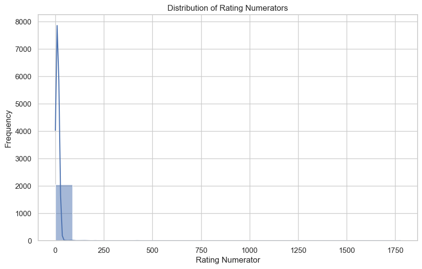

```python
# Plot the distribution of rating numerators
plt.figure(figsize=(10, 6))
sns.histplot(master_df['rating_numerator'], bins=20, kde=True)
plt.title('Distribution of Rating Numerators')
plt.xlabel('Rating Numerator')
plt.ylabel('Frequency')
plt.show()
```

Visualization #2: Most Common Dog Breeds

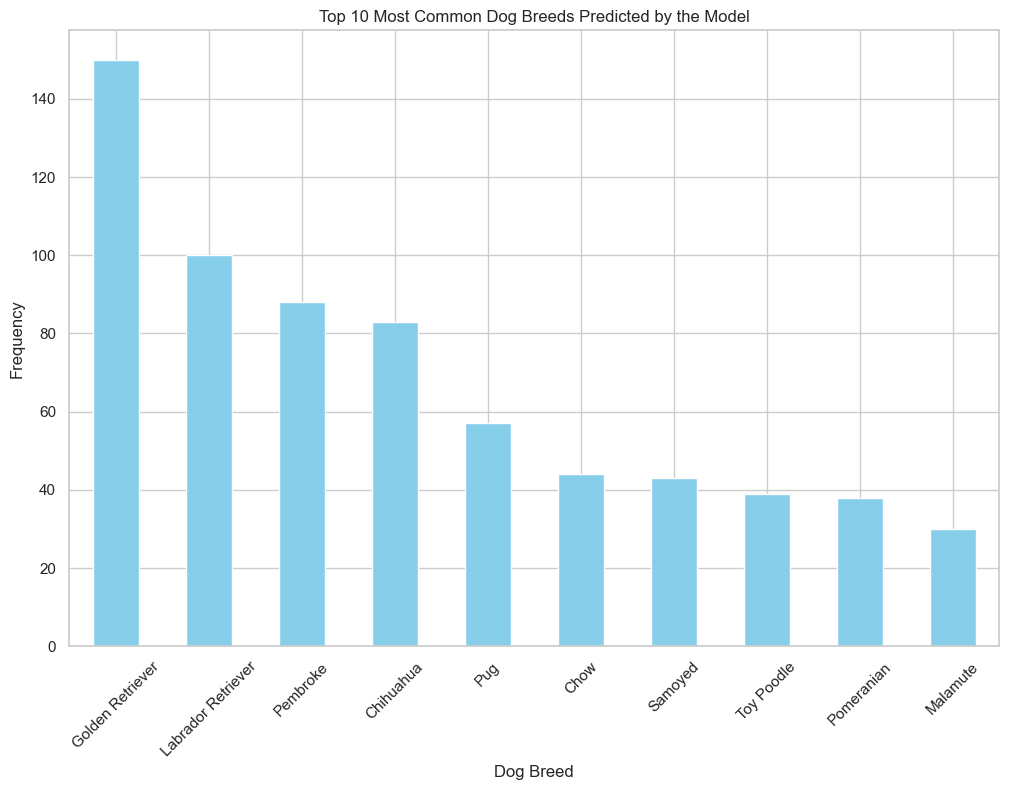

```python
# Plot the most common dog breeds
plt.figure(figsize=(12, 8))
common_breeds.plot(kind='bar', color='skyblue')
plt.title('Top 10 Most Common Dog Breeds Predicted by the Model')
plt.xlabel('Dog Breed')
plt.ylabel('Frequency')
plt.xticks(rotation=45)
plt.show()
```

Visualization #3: Scatter Plot of Retweet Count vs. Favorite Coun

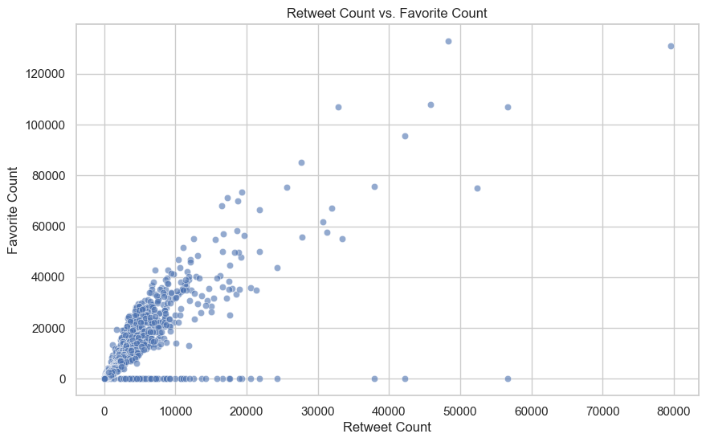

```python
# Plot the scatter plot of retweet count vs favorite count
plt.figure(figsize=(10, 6))
sns.scatterplot(x=master_df['retweet_count'], y=master_df['favorite_count'], alpha=0.6)
plt.title('Retweet Count vs. Favorite Count')
plt.xlabel('Retweet Count')
plt.ylabel('Favorite Count')
plt.show()
```

### Conclusion

In this project, we analyzed, cleaned, and visualized datasets from WeRateDogs. We went through the essential steps of data wrangling, from gathering and assessing data to cleaning and final analysis. Here is a summary of our key steps and findings:

#### Data Gathering

We combined several data sources:

1. The original WeRateDogs Twitter archive dataset.
2. Image predictions of the dog images.
3. Additional tweet data via the Twitter API.

#### Analysis and Visualization

We analyzed and visualized the cleaned data to gain interesting insights:

1. **Most Common Dog Breeds**: We identified and visualized the most frequently predicted dog breeds.
2. **Distribution of Ratings**: We analyzed and visualized the distribution of rating numerators.
3. **Relationship Between Retweets and Favorites**: We analyzed and visualized the correlation between retweet counts and favorite counts.

#### Key Findings

1. **Most Common Dog Breeds**: We found that certain dog breeds like Golden Retrievers and Labrador Retrievers are particularly common in the predictions.
2. **Distribution of Ratings**: The distribution of rating numerators shows that most dogs receive high ratings, reflecting the positive rating culture of WeRateDogs.
3. **Correlation Between Retweets and Favorites**: There is a strong positive correlation between the number of retweets and the number of favorites, indicating that popular tweets are both frequently favorited and retweeted.

#### Conclusion

This project highlighted the importance of data wrangling in analyzing social media data. By combining and cleaning multiple datasets, we were able to derive valuable insights and create meaningful visualizations. These methods and findings can be applied to similar projects to uncover deeper insights from data.

The project not only enhanced our data analysis and cleaning skills but also our ability to tell interesting stories from data. The visualizations and analyses provide a clear and understandable representation of popular WeRateDogs tweets and their characteristics.

Overall, this project demonstrates the power of data analysis and visualization in discovering patterns and trends in social media data.